# Práctica - Análisis de Redes Sociales - MDSF

Javier Herráez Albarrán

Este R Markdown recoge el enunciado de la práctica de la asignatura de redes sociales.

El objetivo es analizar un grafo, que se provee como fichero en el mismo paquete que este enunciado. En este fichero, encontramos solamente dos columnas, correspondiente a una interacción entre dos nodos de la red. Esta red está formada por distintos individuos que tienen contactos cara a cara durante un período de tiempo.

A continuación, dividimos la práctica en apartados, con una breve descripción de qué debe contener cada chunk de código donde el alumno desarrollará su respuesta así como las explicaciones que considere oportunas. Por favor, razona todas tus soluciones y escribe las explicaciones en azul.

Junto al título de cada apartado se encuentra la puntuación del mismo (pueden obtenerse hasta 10,5 puntos, aunque solamente se evaluará del 0 al 10).

## Carga de datos y comprobaciones iniciales (0,5 puntos)

En este apartado, se pide:

- Cargar el fichero adjunto en la práctica.
- Convertirlo en un objeto grafo de IGraph. Se cargará como un grafo NO dirigido.
- Comprobar que, efectivamente, tiene el número de nodos y enlaces correcto.
- Simplificar: eliminar bucles y agregar enlaces múltiples, contando cuántas veces aparece un enlace y almacenándolo como un peso de la red resultante.

```r
library(igraph)
rm(list = ls())

# setwd('C:/Users/Javier/Documents/masterAFI/18. Analisis de Grafos/01. Redes sociales/practica/')
setwd('C:/Users/jherraez/Documents/masterAFI/18. Analisis de Grafos/01. Redes sociales/practica/')
dd <- read.csv('red_contactos.csv', sep = ';')

gg <- graph.data.frame(dd, directed = FALSE)
```

```r
summary(gg)
```

```
## IGRAPH 5876869 UN-- 1390 222744 --
## + attr: name (v/c)
```

```r
vcount(gg)
```

```
## [1] 1390
```

```r
ecount(gg)
```

```
## [1] 222744
```

```r
gg2 <- simplify(gg, remove.multiple = TRUE, remove.loops = TRUE)

E(gg2)$weight = sapply(E(gg2), function(e) {
length(all_shortest_paths(gg, from = ends(gg2, e)[1], to = ends(gg2, e)[2])$res) } )
```

```r
summary(gg)
```

```
## IGRAPH 5876869 UN-- 1390 222744 --
## + attr: name (v/c)
```

```r
table(E(gg2)$weight)
```

```
##
##     1     2     3     4     5     6     7     8     9    10    11    12    13
## 12496 26438  2895  4818  1161  1481   642   739   364   416   278   246   173
##    14    15    16    17    18    19    20    21    22    23    24    25    26
##   193   134   140   106    97    94    71    73    65    54    65    45    45
##    27    28    29    30    31    32    33    34    35    36    37    38    39
##    40    30    37    27    38    23    23    35    18    11    18    19    20
##    40    41    42    43    44    45    46    47    48    49    50    51    52
##    11    15     9    13     9     7     9     7    11     5     8     9    10
##    53    54    55    56    57    58    59    60    61    62    63    64    65
##     7    12     5     8     7     7     3     7     7     5     6     6     7
##    66    67    68    69    70    71    73    74    75    77    78    79    80
##     5     4     4     2     3     3     1     1     1     3     1     1     1
##    81    83    84    85    87    90    92    93    94    95    96    99   101
##     1     1     2     3     2     1     3     1     1     1     1     2     1
##   107   109   110   113   115   120   121   128   129   130   135   136   141
##     1     1     1     1     1     1     1     1     1     1     1     1     1
##   155
##     1
```

## Selección de la componente conexa mayor (0,5 puntos)

En este apartado, se pide realizar los pasos adecuados para generar un nuevo objeto grafo, que sea conexo, y que involucre a todos los nodos y enlaces de la componente conexa mayor del grafo original.

```r
is.connected(gg2) # es conexo?
```

```
## [1] FALSE
```

```r
ccs <- components(gg2)
ccs$csize
```

```
## [1] 1388    1    1
```

```r
id_compmayor <- which.max(ccs$csize) # mayor componente conexa

vids <- ccs$membership == id_compmayor
vids <- which(ccs$membership == id_compmayor) #nodos de la comp conexa mayor

gg3 <- induced_subgraph(gg2, vids = vids ) #subbgrafo solamente con estos nodos

summary(gg3)
```

```
## IGRAPH 8362c06 UNW- 1388 53942 --
## + attr: name (v/c), weight (e/n)
```

## Análisis descriptivo de la componente conexa mayor (2,5 puntos)

En este apartado, se pide analizar descriptivamente el grafo usando los conceptos que hemos visto durante las clases de teoría:

- Grado medio
- Distancia media
- Diámetro
- Distribución de grados y ajuste a una Power-Law
- Clustering
- Entropía de los nodos
- Centralidad de los nodos y comparación con métricas de grado y clustering

```r
# grado medio
mean(degree(gg3))
```

```
## [1] 77.72622
```

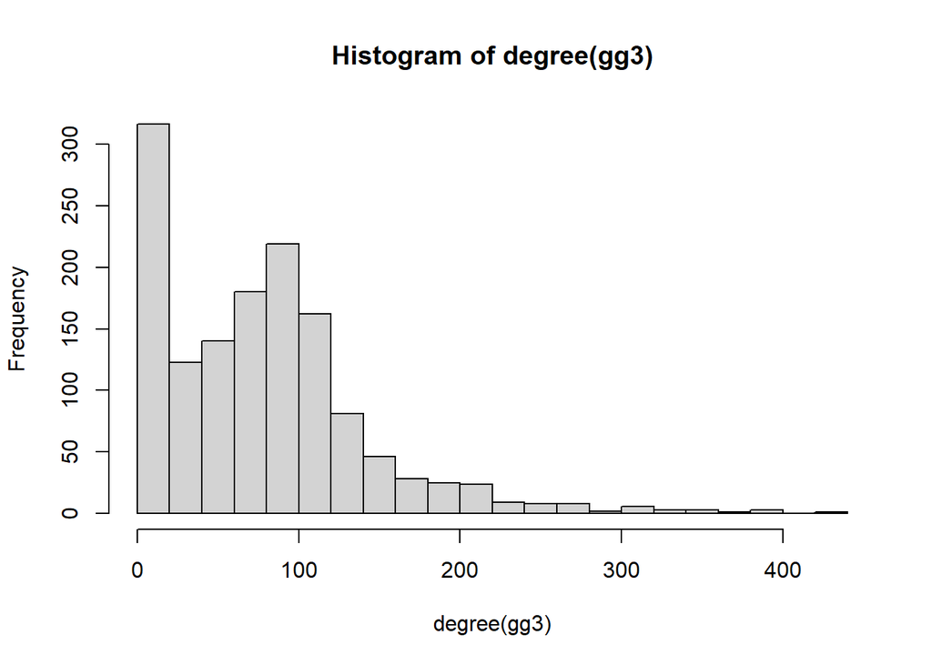

```r
hist(degree(gg3), breaks = 20)
```

```r
# distancia media
average.path.length(gg3)
```

```
## [1] 3.066029
```

```r
# diámetro
diameter(gg3)
```

```
## [1] 14
```

```r
# Distribución de grados y ajuste a una Power-Law
graph.density(gg3)
```

```
## [1] 0.0560391
```

```r
deg_dist <- degree_distribution(gg3)
fit <- fit_power_law(deg_dist)
fit
```

```
## $continuous
## [1] TRUE
##
## $alpha
## [1] 3.447821
##
## $xmin
## [1] 0.005043228
##
## $logLik
## [1] 391.6632
##
## $KS.stat
## [1] 0.1568648
##
## $KS.p
## [1] 0.03535439
```

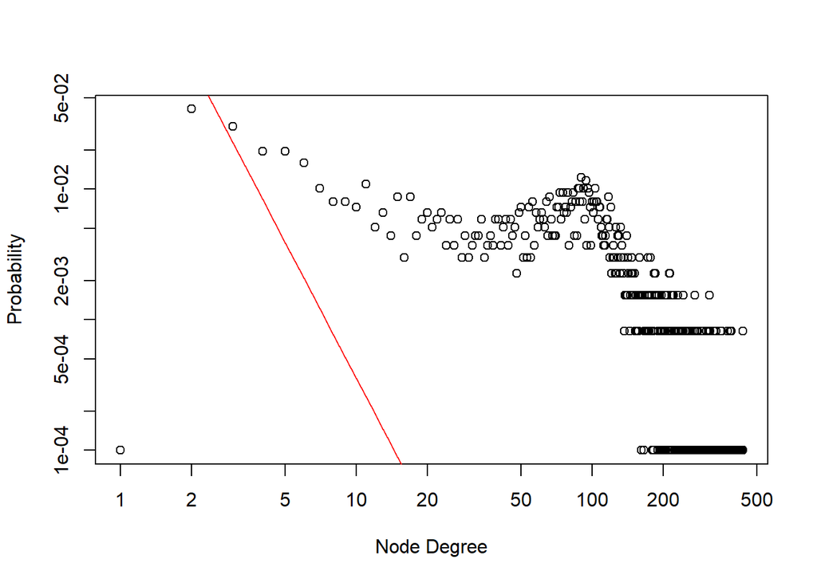

```r
# plot the degree distribution on a log-log plot
plot(deg_dist + 0.0001,
log = 'xy',
xlab = 'Node Degree',
ylab = 'Probability')

# add the fitted power law line; the exponent value comes from alpha, part of
# the output of the fit.power.law() function.
lines(seq(deg_dist),
seq(deg_dist)^-fit$alpha,
col='red')
```

```r
# Clustering
mean(count_triangles(gg3))
```

```
## [1] 1037.44
```

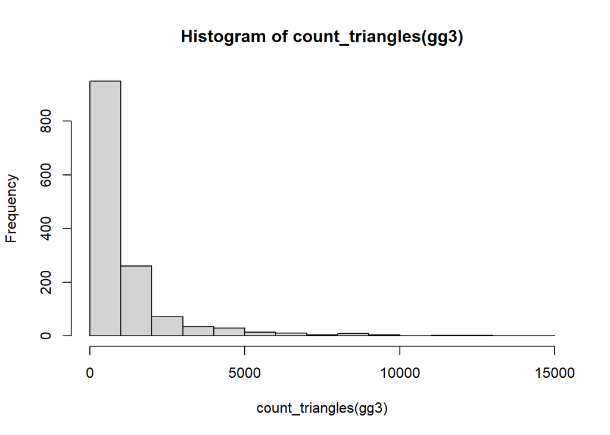

```r
hist(count_triangles(gg3), breaks = 20)
```

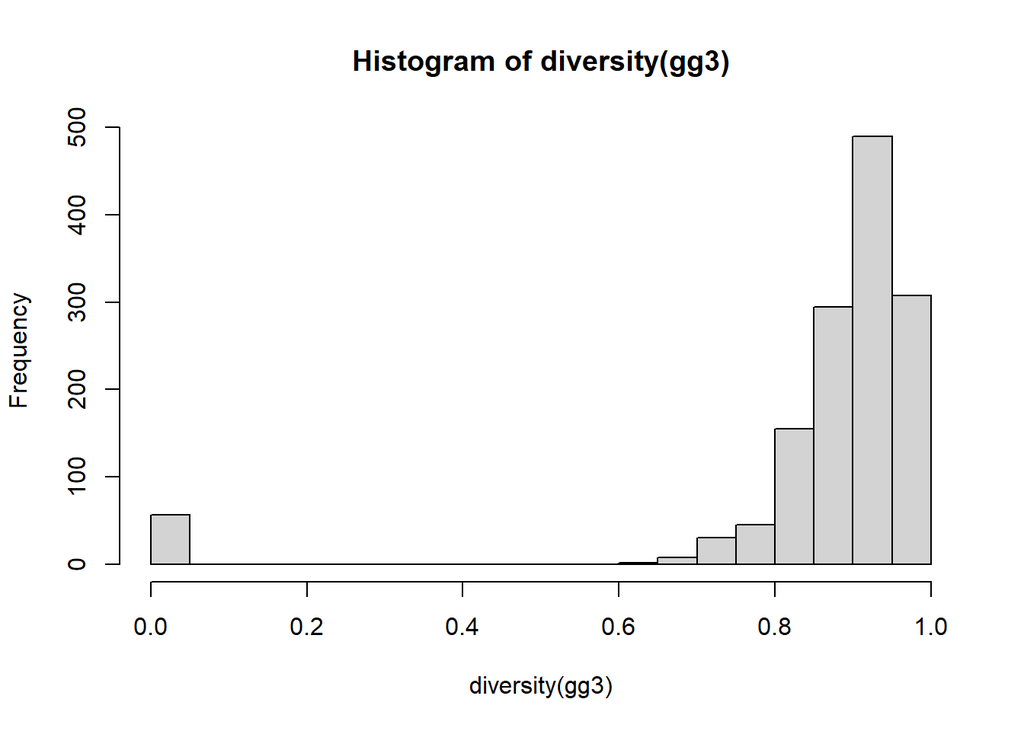

```r
# Entropía de los nodos Shannon
hist(diversity(gg3), breaks = 20)
```

```r
# Centralidad de los nodos y comparación con métricas de grado y clustering
Degree <- degree(gg3)
Eig <- evcent(gg3)$vector
Closeness <- closeness(gg3)
Betweenness <- betweenness(gg3)

centralities <- cbind(Degree, Eig, Closeness, Betweenness)
round(cor(centralities), 2)
```

```
##             Degree  Eig Closeness Betweenness
## Degree        1.00 0.93      0.79        0.85
## Eig           0.93 1.00      0.69        0.78
## Closeness     0.79 0.69      1.00        0.59
## Betweenness   0.85 0.78      0.59        1.00
```

## Análisis de comunidades de la componente conexa mayor (1,5 puntos)

En este apartado, se pide aplicar dos algoritmos de detección de comunidades, compararlos y seleccionar cuál es, en tu opinión, el que da una mejor respuesta. Razona tu selección.

```r
#### infomap, fastgreedy, label propagation, walktrap

comms_infomap <- infomap.community(gg3)
comms_walktrap <- walktrap.community(gg3)

modularity(comms_infomap)
```

```
## [1] 0.4683851
```

```r
modularity(comms_walktrap)
```

```
## [1] 0.4634219
```

```r
compare(comms_infomap, comms_walktrap, method='nmi')
```

```
## [1] 0.812869
```

```r
table(comms_infomap$membership)
```

```
##
##   1   2   3   4   5   6   7   8   9  10  11  12  13  14  15  16  17  18  19  20
##   9  55 392  45  26  11  37  25  12  30  61  87  22  52  57  60  35   4  13  18
##  21  22  23  24  25  26  27  28  29  30  31  32  33  34  35  36  37  38  39  40
##  31  35   1  17  38  13   3  25   6  41  10  22  14   3  37  13   7   8   6   3
##  41  42
##   2   2
```

```r
table(comms_walktrap$membership)
```

```
##
##   1   2   3   4   5   6   7   8   9  10  11  12  13  14  15  16  17  18  19  20
##  14  12  42  13 134 396  29  50  53  54  28  46   8  15  17  97   2   4  52  83
##  21  22  23  24  25  26  27  28  29  30  31  32  33  34  35  36  37  38  39  40
##   5  10  16   7  30  13  19  32  17   2   2   1   1   1   1   1   1   1   1   1
##  41  42  43  44  45  46  47  48  49  50  51  52  53  54  55  56  57  58  59  60
##   1   1   1   1   1   1   1   1   1   1   1   1   1   1   1   1   1   1   1   1
##  61  62  63  64  65  66  67  68  69  70  71  72  73  74  75  76  77  78  79  80
##   1   1   1   1   1   1   1   1   1   1   1   1   1   1   1   1   1   1   1   1
##  81  82  83  84  85  86  87  88  89  90  91  92  93  94  95  96  97  98  99 100
##   1   1   1   1   1   1   1   1   1   1   1   1   1   1   1   1   1   1   1   1
## 101 102 103 104 105 106 107 108 109 110 111 112 113 114 115 116 117
##   1   1   1   1   1   1   1   1   1   1   1   1   1   1   1   1   1
```

## Visualización del grafo por comunidades de la componente conexa mayor (1,5 puntos)

En este apartado, se pide visualizar el grafo coloreando cada nodo en función de la comunidad a la que pertenezca, según tu elección del apartado anterior.

```r
wws <- ifelse(crossing(comms_infomap, gg3), 1, 500)
ll <- layout_with_fr(gg3, weights=wws)

palcol <- rainbow(n=max(comms_infomap$membership))

plot(gg3,
layout = ll,
vertex.label='',
vertex.size=log(degree(gg3)),
vertex.color=palcol[comms_infomap$membership])
```

[figure not shown]

## Difundiendo un rumor (o un virus) en la componente conexa mayor (4 puntos)

Este apartado es el que más peso en la práctica tiene. Vamos a implementar un modelo epidemiológico sobre el grafo que, típicamente, se utiliza para simular escenarios de difusión de enfermedades pero también en contextos como la distribución de rumoeres e información. Vamos a implementar un modelo SIR que se caracteriza por tener los siguientes parámetros:

- Número de nodos iniciales infectados en el momento t=0 (N).
- Beta: probabilidad de contagio de un nodo infectado (I) a un nodo susceptible de serlo (S)
- Gamma: probabilidad de que un nodo infectado (I) se recupere en momenteo actual (R). Los nodos en estado (R) no son susceptibles y permanecen en este estado infinitamente.

Se pide desarrollar una función que tenga como parámetros los tres valores anteriores y un cuarto que sea un grafo que, en nuestro caso, será la componente conexa mayor del grafo original de esta práctica. Dicha función simulará el proceso SIR:

- En t=0, se seleccionan N nodos al azar, que pasarán a estado infectado.
- En t=1, se podrán contagiar con probabilidad Beta nodos que tienen un vecino infectado; OJO: si un nodo en estado S tiene varios vecinos en estado I tiene más probabilidad de infectarse ya que cada vecino tendrá un intento de infectarle.
- Se repite el paso anterior sucesivamente, hasta que no vemos infectados nuevos durante, al menos, 3 iteraciones.

Se pide ejecutar una simulación para tres o cuatro valores del parámetro beta (N y gamma pueden ser fijos en estas simulaciones) de este proceso de manera que se pueda visualizar:

- La curva de nuevos infectados en escala logarítmica para cada caso.
- El grafo que surge de la cascada de contagios: es decir, dos nodos están enlazados ahora si uno ha contagiado al otro. Como es lógico, tanto los nodos como los enlaces de este nuevo grafo son un subconjunto del grafo original.

```r
generate_sir <- function(N = 5, beta = 0.1, gamma = 0.1, graph){
  graph <- set_vertex_attr(graph, 'label', value = 'S')

  sample_index <- sample(1:vcount(graph), N)
  graph <- set_vertex_attr(graph, 'label', index = sample_index, value = 'I')

  n_contagiados = N
  n_susceptibles = vcount(graph) - N
  n_recuperados = 0
  dias_sin_contagios = 0

  lista_contagiados = c(n_contagiados)
  lista_susceptibles = c(n_susceptibles)
  lista_recuperados = c(n_recuperados)
  dia = 1

  while (dias_sin_contagios < 3){
    n_contagiados_iniciales = n_contagiados
    n_contagiados_aux = n_contagiados

    for (v in V(graph)){
      state <- V(graph)[v]$label

      if (state == 'I'){
        if (rbinom(n=1, size=1, prob = gamma) == 1){
          V(graph)[v]$label <- 'R'
          n_recuperados = n_recuperados + 1
          n_contagiados = n_contagiados - 1
        }
      }
      if (state == 'S'){
        for (neighbor in neighbors(graph, v)){
          if (V(graph)[neighbor]$label == 'I'){
            if (rbinom(n=1, size=1, prob = beta) == 1){
              V(graph)[v]$label <- 'I'
              n_contagiados = n_contagiados + 1
              n_contagiados_aux = n_contagiados_aux + 1
              n_susceptibles = n_susceptibles - 1
              break
            }
          }
        }
      }
    }
    if (n_contagiados_iniciales == n_contagiados_aux){
      dias_sin_contagios = dias_sin_contagios + 1
    } else {
      dias_sin_contagios = 0
    }
    lista_contagiados = c(lista_contagiados, n_contagiados)
    lista_susceptibles = c(lista_susceptibles, n_susceptibles)
    lista_recuperados = c(lista_recuperados, n_recuperados)
    dia = dia + 1
  }

  return (list('final_state' = V(graph)$label,
               'contagiados' = lista_contagiados,
               'susceptibles' = lista_susceptibles,
               'recuperados' = lista_recuperados,
               'dias' = dia
          ))

}

plot_evolution <- function(evolution){
  plot(1:evolution$dias, evolution$contagiados, type = 'l', col = 'red',
       ylab = 'Nº Personas', xlab = 'Días', ylim = c(0, max(evolution$susceptibles)))
  lines(1:evolution$dias, evolution$recuperados, type = 'l', col="green")
  lines(1:evolution$dias, evolution$susceptibles, type = 'l', col="blue")

  legend(evolution$dias, max(evolution$susceptibles)/2,
         legend=c('Contagiados', 'Recuperados', 'Susceptibles'),
         col=c("red", 'green', "blue"), lty=1, cex=0.8, xjust = 1)
}
```

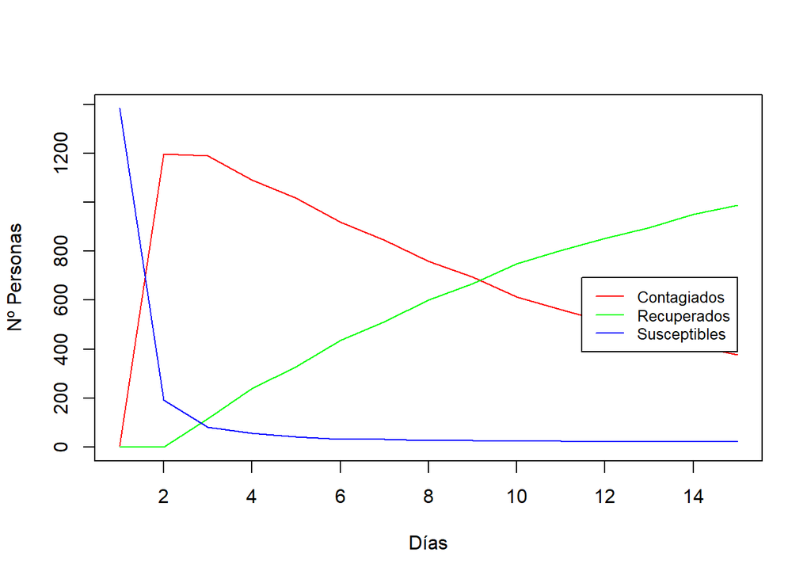

```r
ejemplo_SIR_1 <- generate_sir(graph = gg3, N = 5, beta = 0.2)

plot_evolution(ejemplo_SIR_1)
```

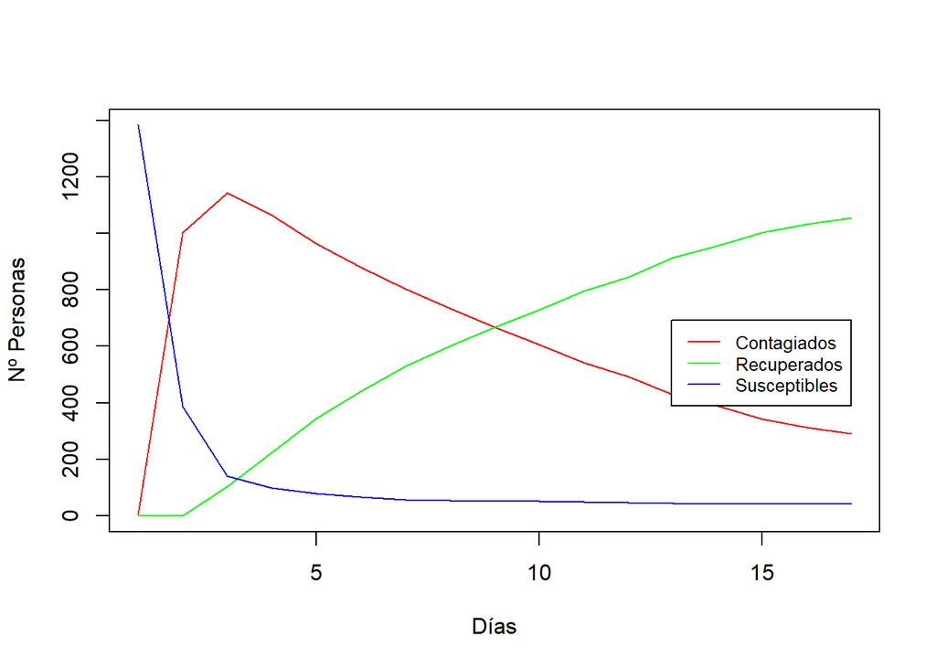

```r
ejemplo_SIR_2 <- generate_sir(graph = gg3, N = 5, beta = 0.1)

plot_evolution(ejemplo_SIR_2)
```

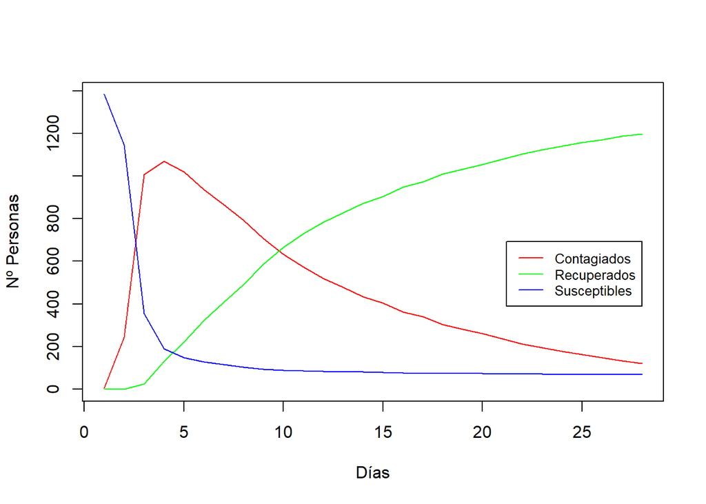

```r
ejemplo_SIR_3 <- generate_sir(graph = gg3, N = 5, beta = 0.05)

plot_evolution(ejemplo_SIR_3)
```

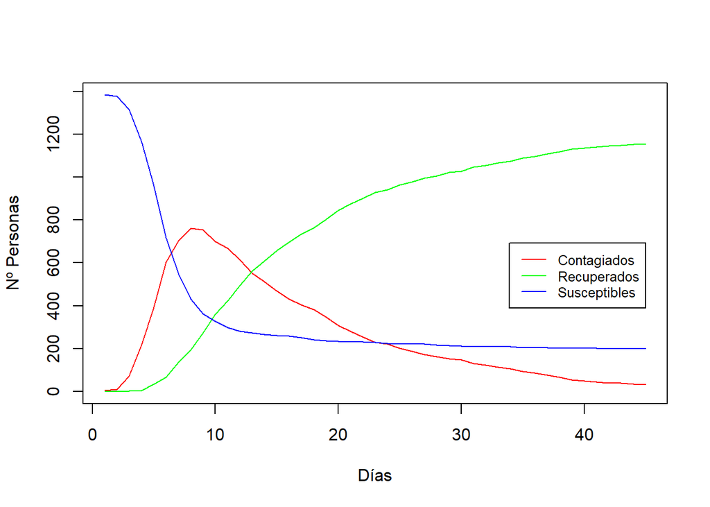

```r
ejemplo_SIR_4 <- generate_sir(graph = gg3, N = 5, beta = 0.01)

plot_evolution(ejemplo_SIR_4)
```